# KU Twitter analysis

*JOUR 864 - Mike Williams - social media data visualization assignment*

#### packages needed

```r
#install.packages('tidyverse')
library(tidyverse)
```

#### Set up and clean the data

```r
tweets <- read_csv("tweets_new.csv")

count_by_date <- tweets %>% group_by(created_at) %>% tally()

source_count <- tweets %>% group_by(source) %>% tally()
source_count <- arrange(source_count, desc(n))
source_count <- slice(source_count, 1:15)
```

## How I use twitter

Journalism today in a way relies on Twitter as a storytelling tool. Whether that’s by source gathering, event coverage or story tips, the social media tool has placed itself as a necessity in today’s media landscape.

I recently had my Twitter account verified through work, and although it may be too soon to tell if my current or future platform use will change because of it, it’s something I plan to pay attention to. With this in mind, I wanted to see how I have utilized Twitter in the past by measuring my frequency of tweets sent over time, if they were retweets or original tweets, and how often they were sent via phone or computer.

```r
#same results as grouping and tally of `count_by_date` dataframe
#tally only shows data and count though, using the tweets data shows content too
tweets %>% count(created_at) %>% arrange(desc(n))
```

| created_at | n |
| --- | --- |
| 2011-09-23 | 106 |
| 2012-10-10 | 85 |
| 2011-11-13 | 58 |
| 2012-04-25 | 41 |
| 2012-02-15 | 37 |
| 2011-09-28 | 35 |
| 2016-09-17 | 31 |
| 2017-04-14 | 26 |
| 2012-07-28 | 25 |
| 2011-10-26 | 24 |

[output cut: 2223 more lines]

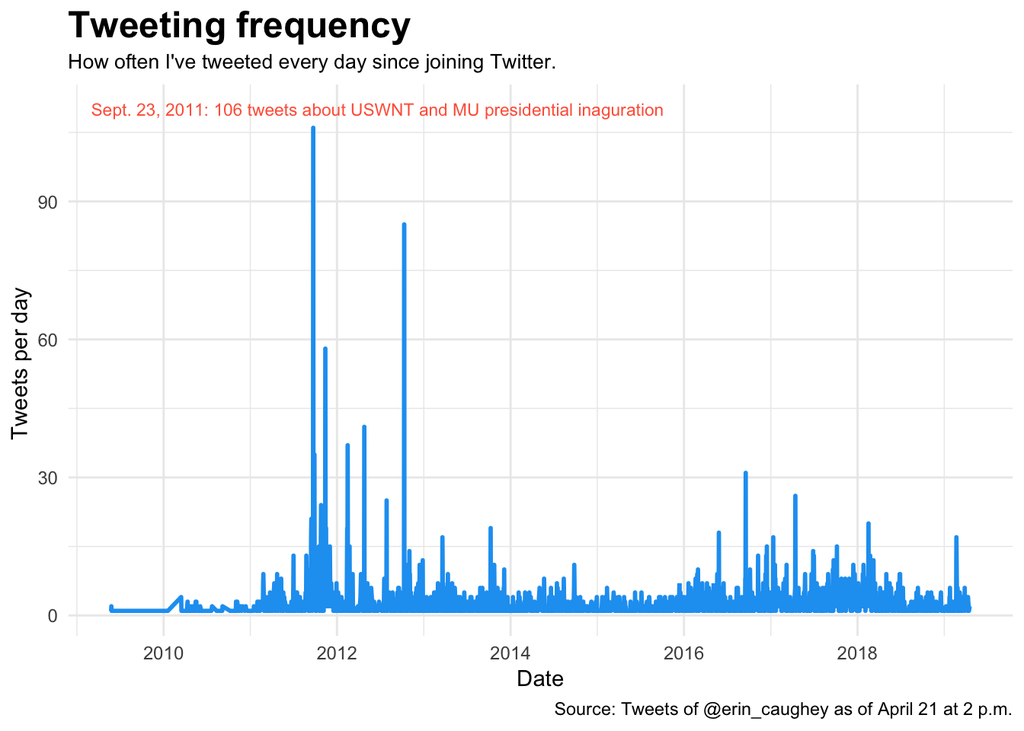

```r
# frequency timeseries
timeseries <- ggplot(data = count_by_date, aes(x = created_at, y = n)) +
  geom_line(color = "#1DA1F2", size = 1)
timeseries +
  annotate(geom="text",x=as.Date("2012-06-20"), y=110, label="Sept. 23, 2011: 106 tweets about USWNT and MU presidential inaguration", colour = "tomato", size=3) +
  labs(x="Date", y="Tweets per day ", title="Tweeting frequency", subtitle="How often I've tweeted every day since joining Twitter.", caption="Source: Tweets of @erin_caughey as of April 21 at 2 p.m.") +
  theme_minimal() +
  theme(
    plot.title = element_text(size = 18, face = "bold"),
    plot.subtitle = element_text(size=10),
    axis.text = element_text(size = 9),
    axis.ticks = element_blank()
  )
```

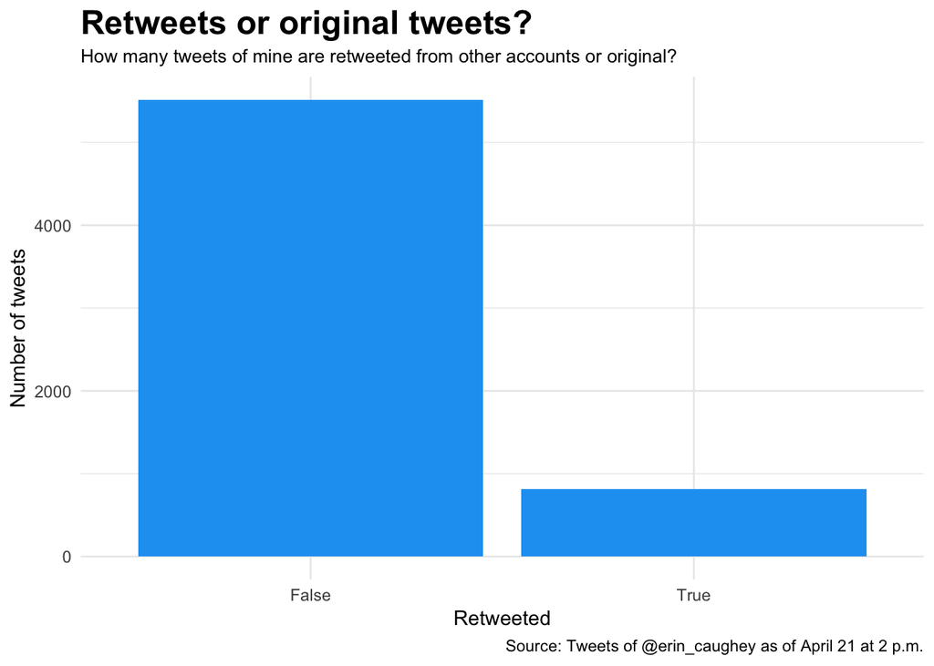

```r
# Retweet True / False count
tf <- ggplot(tweets, aes(retweeted))
tf + geom_bar(fill = "#1DA1F2") +
  labs(x="Retweeted", y="Number of tweets", title="Retweets or original tweets?", subtitle="How many tweets of mine are retweeted from other accounts or original?", caption="Source: Tweets of @erin_caughey as of April 21 at 2 p.m.") +
  theme_minimal() +
  theme(
      plot.title = element_text(size = 18, face = "bold"),
      plot.subtitle = element_text(size=10),
      axis.text = element_text(size = 9),
      axis.ticks = element_blank()
    )
```

Based on my current Twitter usage I found the above graphic surprising. As of late I feel I retweet more than tweet original content. Although I’m not confident what Twitter is actually counting as retweet vs. original. My assumption is that anytime I retweet with my own comments, it’s counted as an original tweet. This would make more send given the outcome of the data.

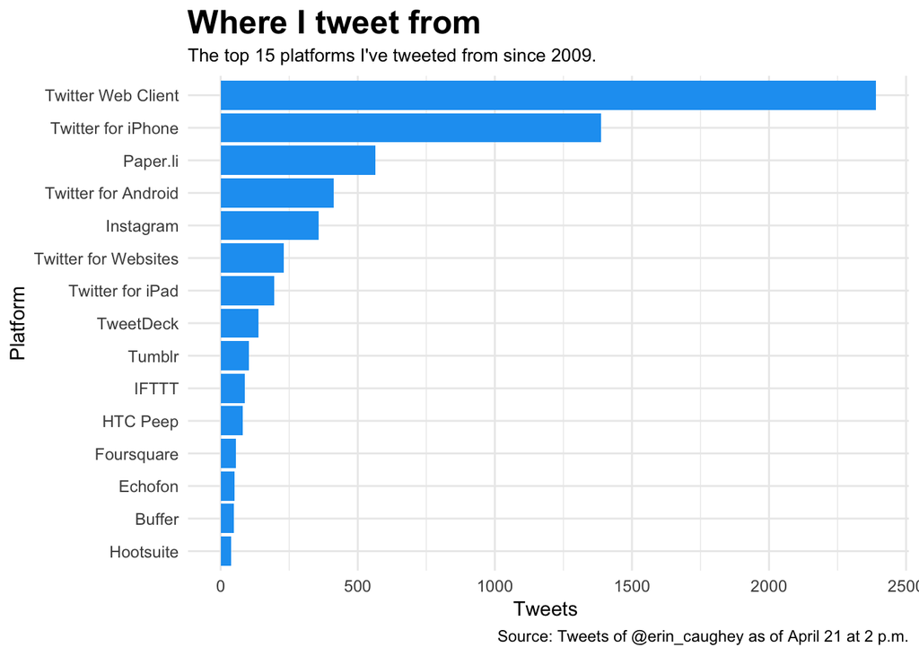

```r
# Tweet source count
client <- ggplot(source_count, aes(x=reorder(source, n), y=n))
client + geom_bar(stat = "identity", fill = "#1DA1F2") +
  labs(x="Platform", y="Tweets ", title="Where I tweet from", subtitle="The top 15 platforms I've tweeted from since 2009.", caption="Source: Tweets of @erin_caughey as of April 21 at 2 p.m.") +
  theme_minimal() +
  theme(
    plot.title = element_text(size = 18, face = "bold"),
    plot.subtitle = element_text(size=10),
    axis.text = element_text(size = 9),
    axis.ticks = element_blank()
  ) +
  coord_flip()
```

**Methodology:** Tweets by [@erin_caughey](https://twitter.com/erin_caughey) were scrapped with the tweepy.org python script. Analysis and graphics of time and frequency of tweets was done with tidyverse and ggplot R packages.

Since being a journalist today pretty much requires that you’re plugged in to social media constatnly throughout the day, I’m not surprised by the amount I tweet from the Twitter Web Client or iPhone. This however, was a good reminder for me to check what platforms have access to my Twitter account and lead to some personal doxxing of my information.

This same process can be used on other Twitter accounts to check for patterns. For example, in recent years one of the primary reasons journalists rely on Twitter so often is because our President has taken to using it as his microphone. If I were to scrape Donald Trump’s tweets and check the same frequency, retweets and platform use the picture would be very different from my own social use. We’d most likely see a boom of frequency in the months prior to his presidential race announcement. We’d see an overwhelming majority of original tweets. And we’d most likely see a higher use of mobile Twitter client platforms. The data I scrapped also provides counts of how many times each tweet was retweeted. Retweets of my original content is very low, therefore not interesting. However, the amount of retweets on President Trump’s tweets could show a different pattern.

These three focus areas provide a very broad view of my Twitter usage. The next step in analyzing this data could be to compare my tweet frequency by similar months over the years, or how frequency corresponds to major events using small multiples or through a calendar heatmap.